# 2020 Q

## Raw Poker PT2

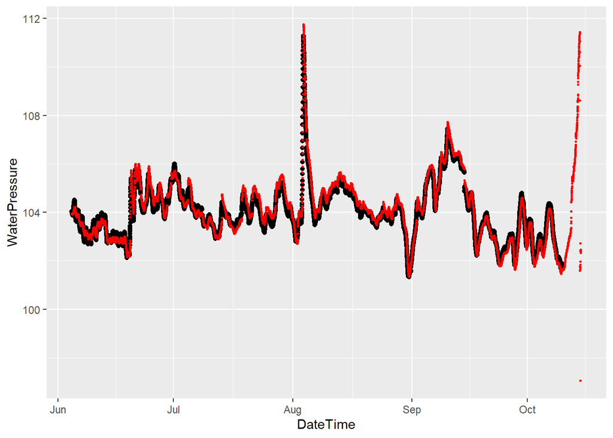

Because the two PTs are very close maybe we should not do any shifting.

Poker PT2 2.0

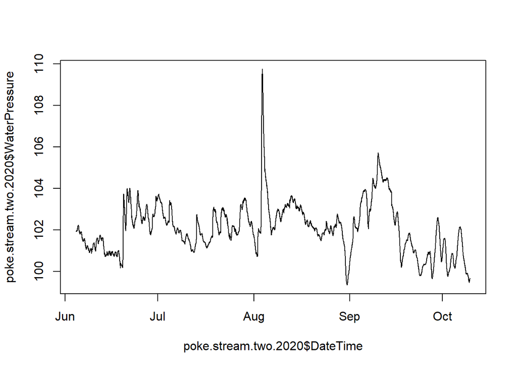

Air Pressure

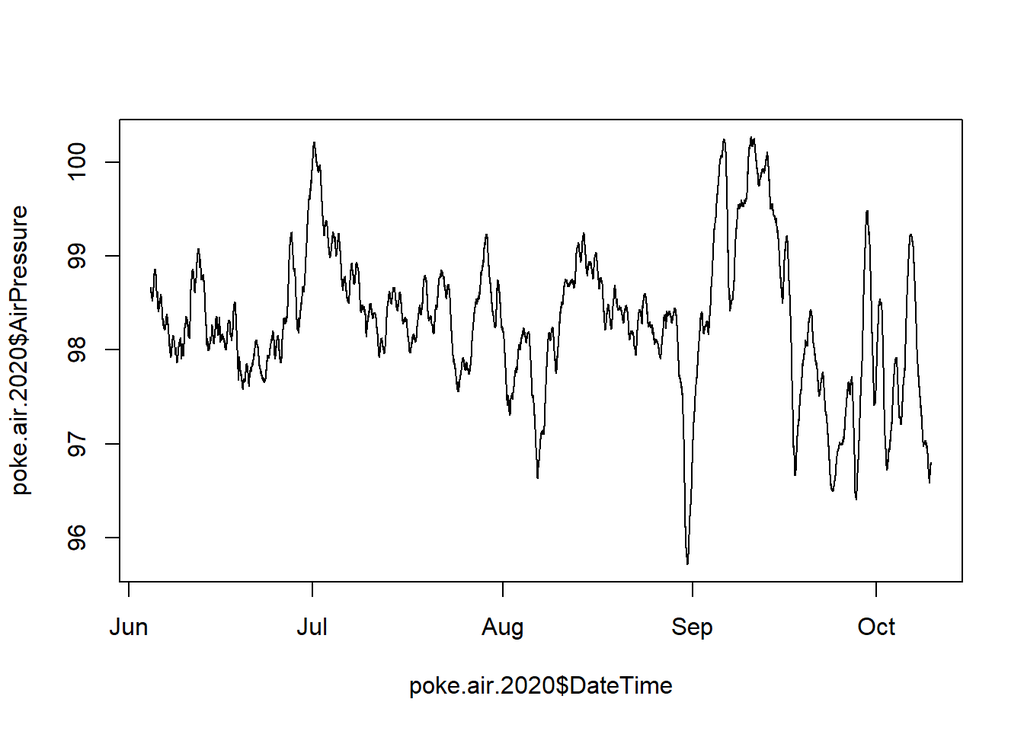

## Export PT data to csv in DoD_Discharge->PT_data->2020

# Take difference

## Raw Rating curve POKE PT1

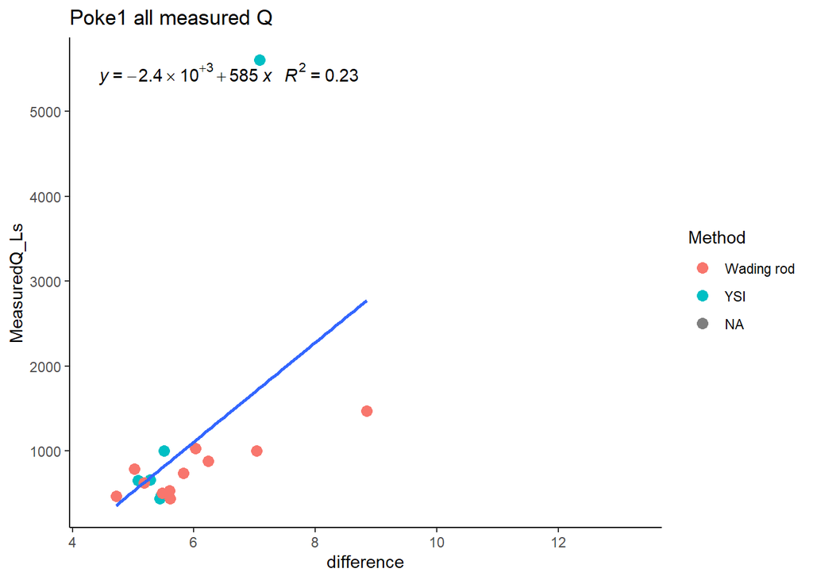

Top YSI point has got to go.

Rating curve POKE PT1 2.0

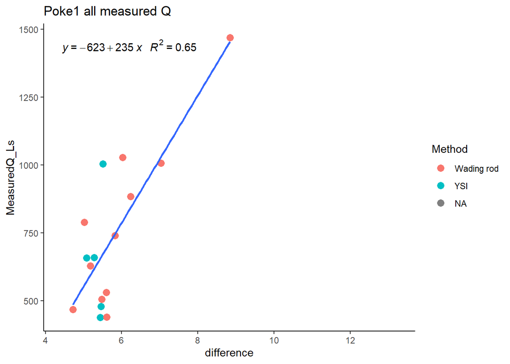

1. removed the top YSI point

## Raw Rating curve POKE PT2

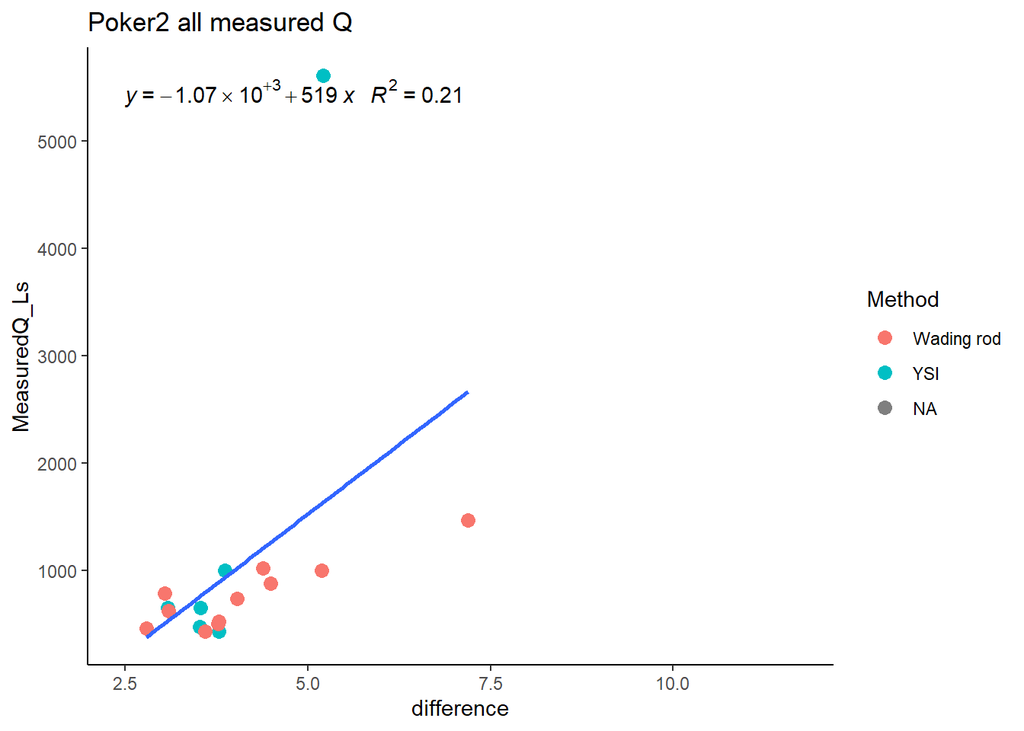

Need to remove the top YSI point and lowest water level YSI point.

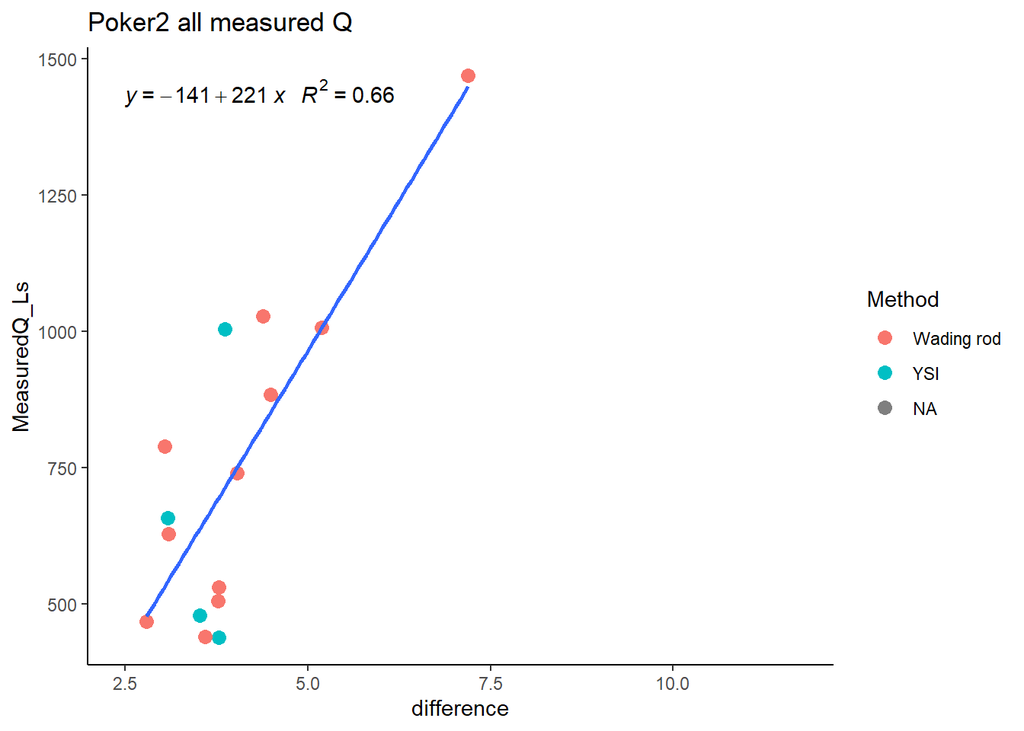

## Final Q for POKE PT1

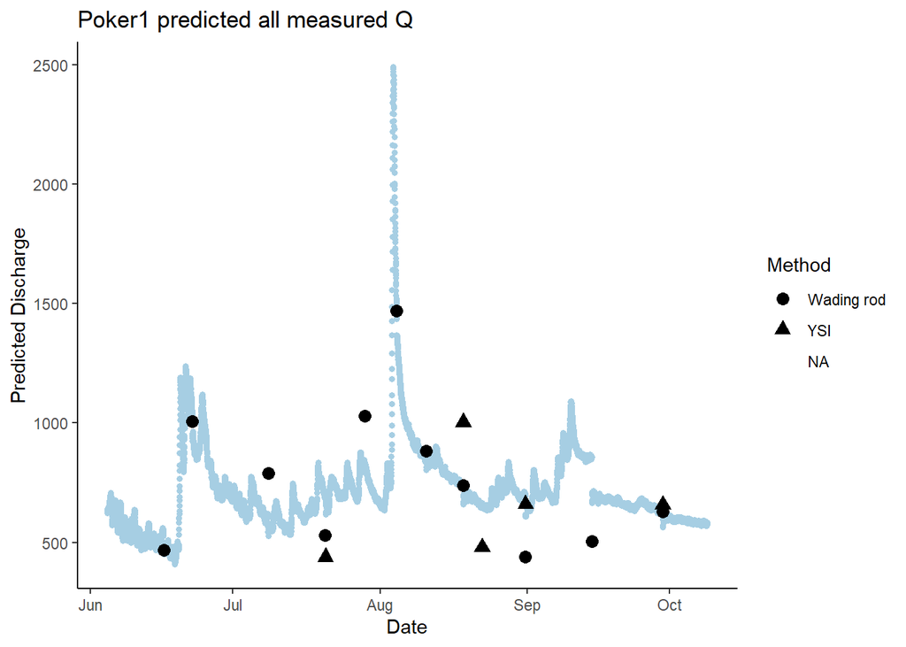

Seems like the predicted overshoots our discrete measurements

## Final Q for POKE PT2

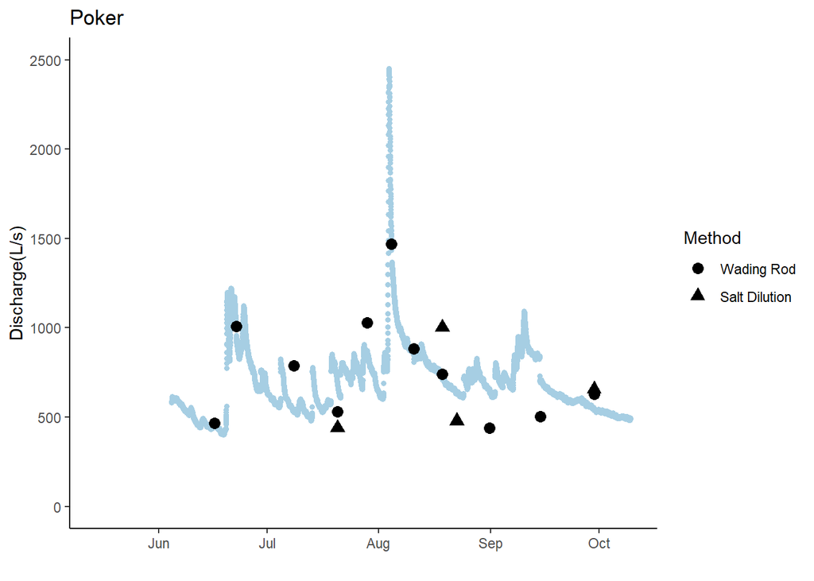

## Final Q POKE average

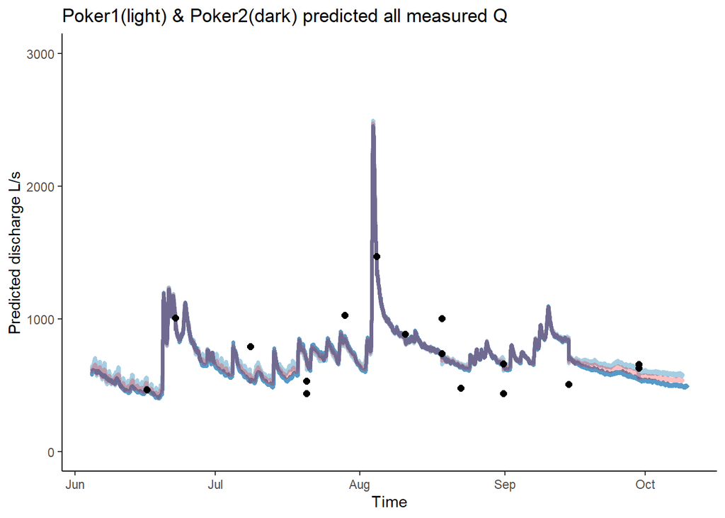

## Export PT data to csv in DoD_Discharge->Predicted_Discharge->2020

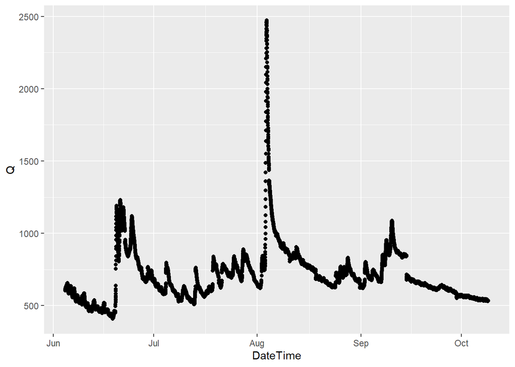

## Raw Vault PT2

There is only one good Vault PT

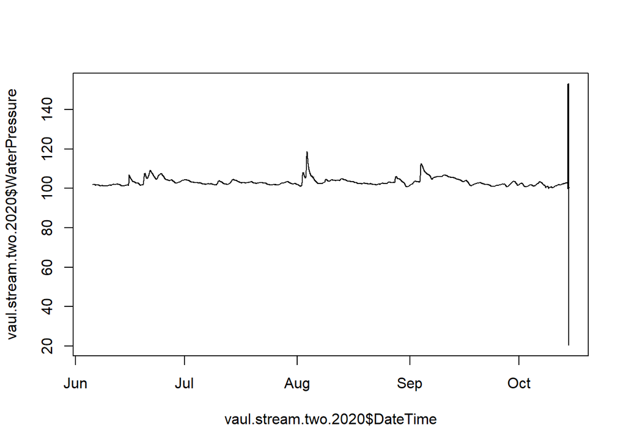

Hard to see what else we need to clean besides the end of the year out of water points….let the cleaning commence!

## Vault PT2 2.0

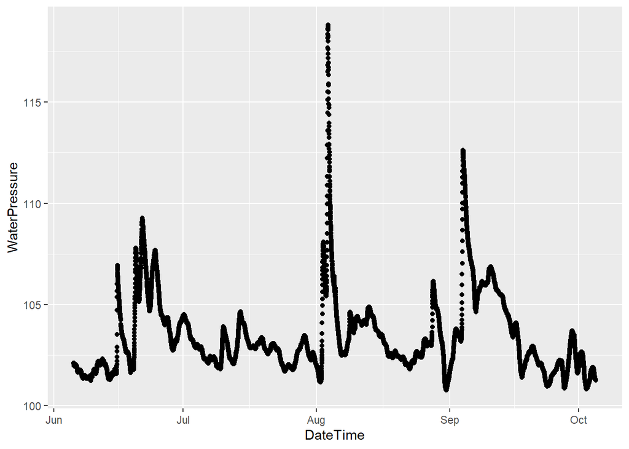

1. removed data after 10/5/20 due to out of water points

Vault air pressure

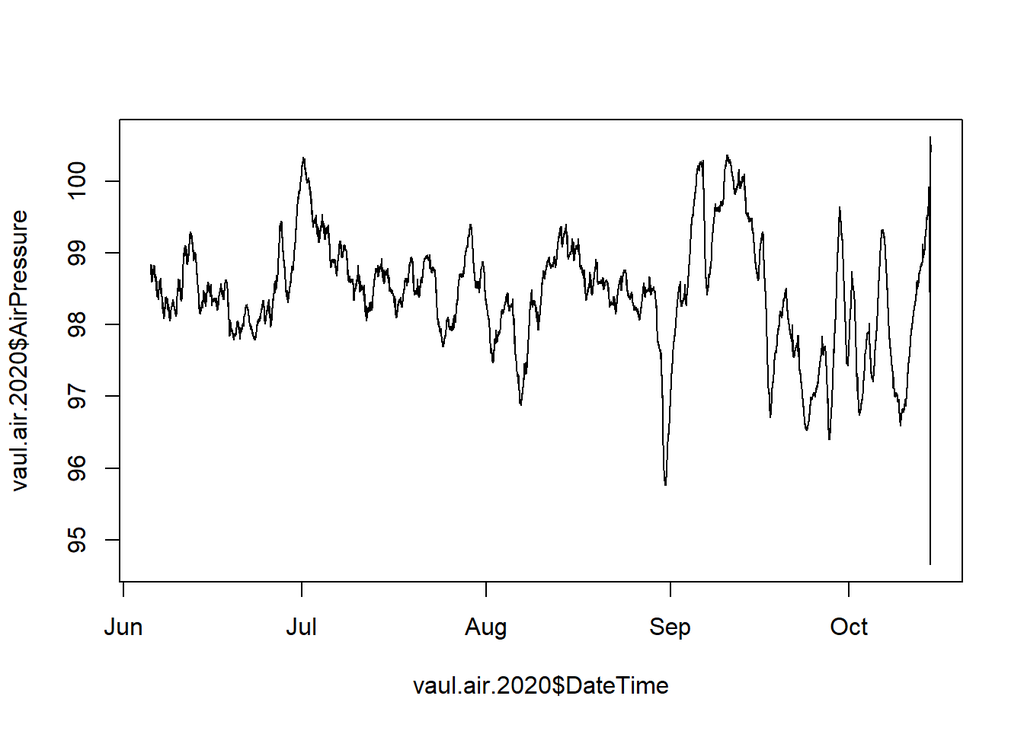

## Take difference and export PT data to csv in DoD_Discharge->PT_data->2020

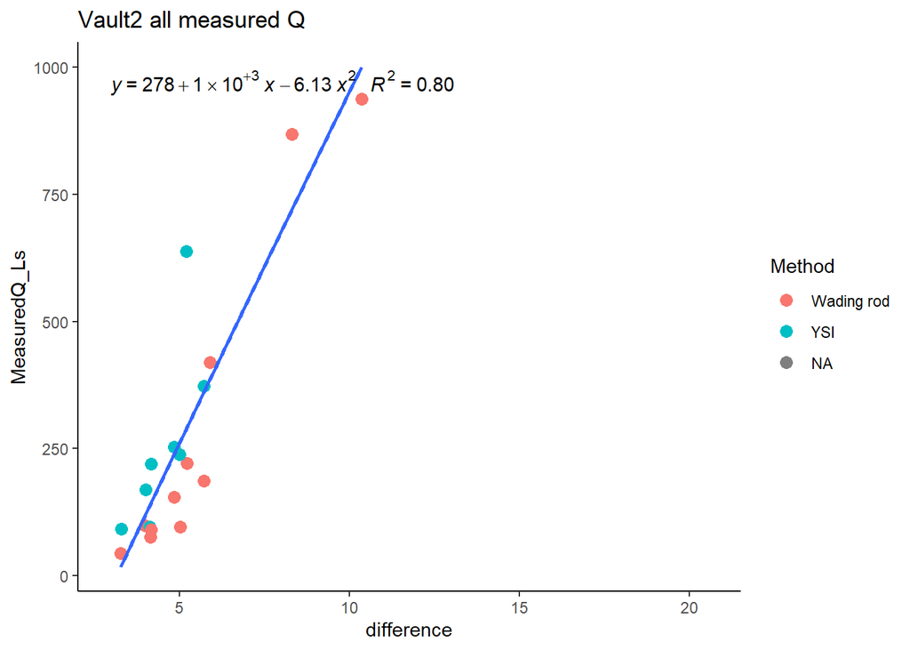

This gives many negative values for predicted Q, so lets only use one high point.

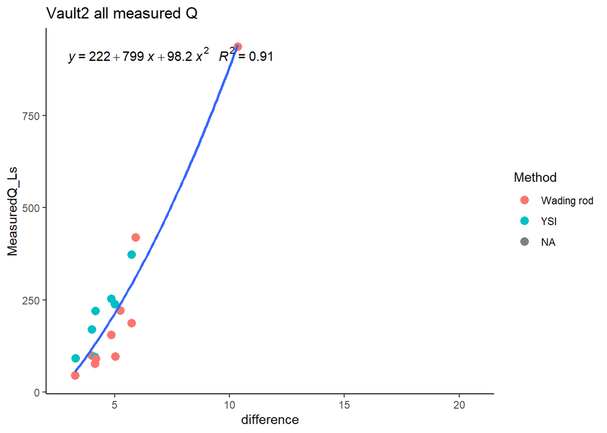

## Predicted Q for VAUL

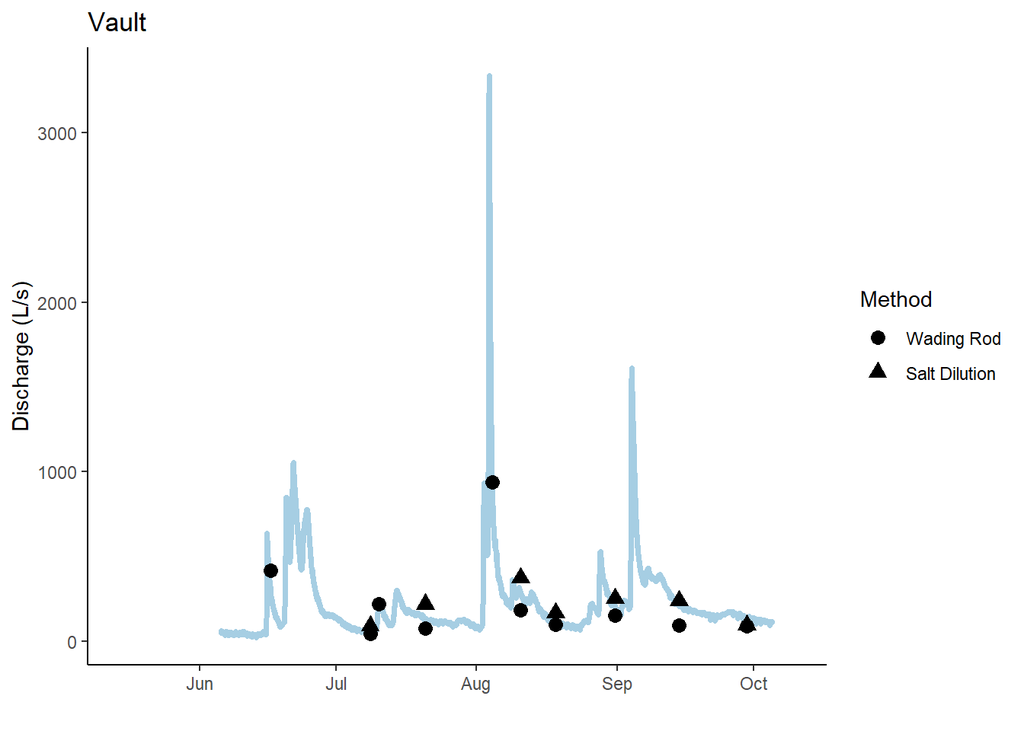

Not too shabby!

## Export PT data to csv in DoD_Discharge->Predicted_Discharge->2020

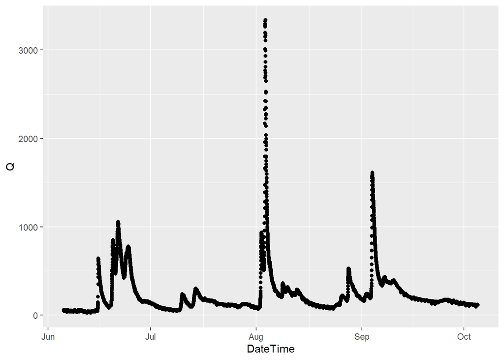

# Stuart

## Raw STRT PT1

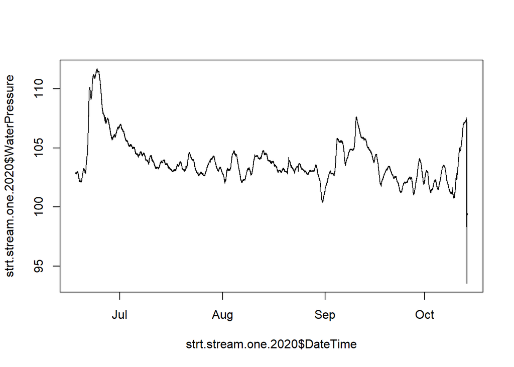

Needs end of season out of water points to be removed….let the cleaning commence!

STRT PT1 2.0

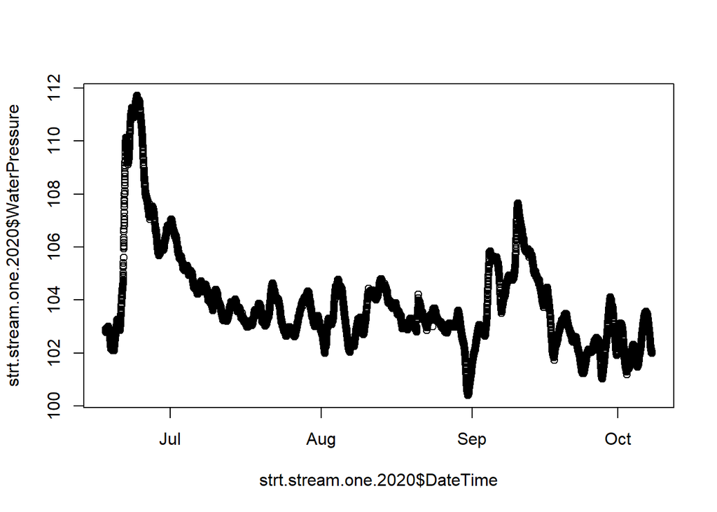

1. Removed data after 10/8/20 due to ice on the channel…PT was taken out on the 13th
2. removed vertical bar errant point in middle of August

## Raw STRT PT2

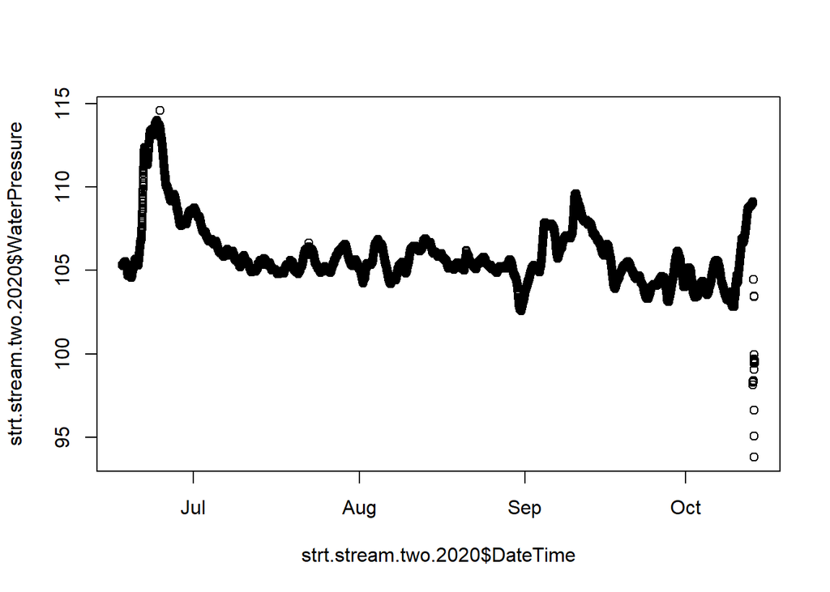

Same procedure as previous PT….let the cleaning commence!

STRT PT2 2.0

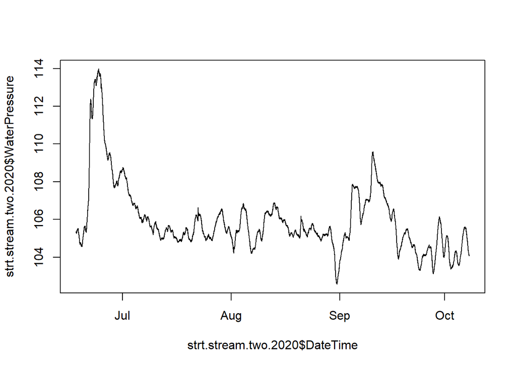

Air Pressure

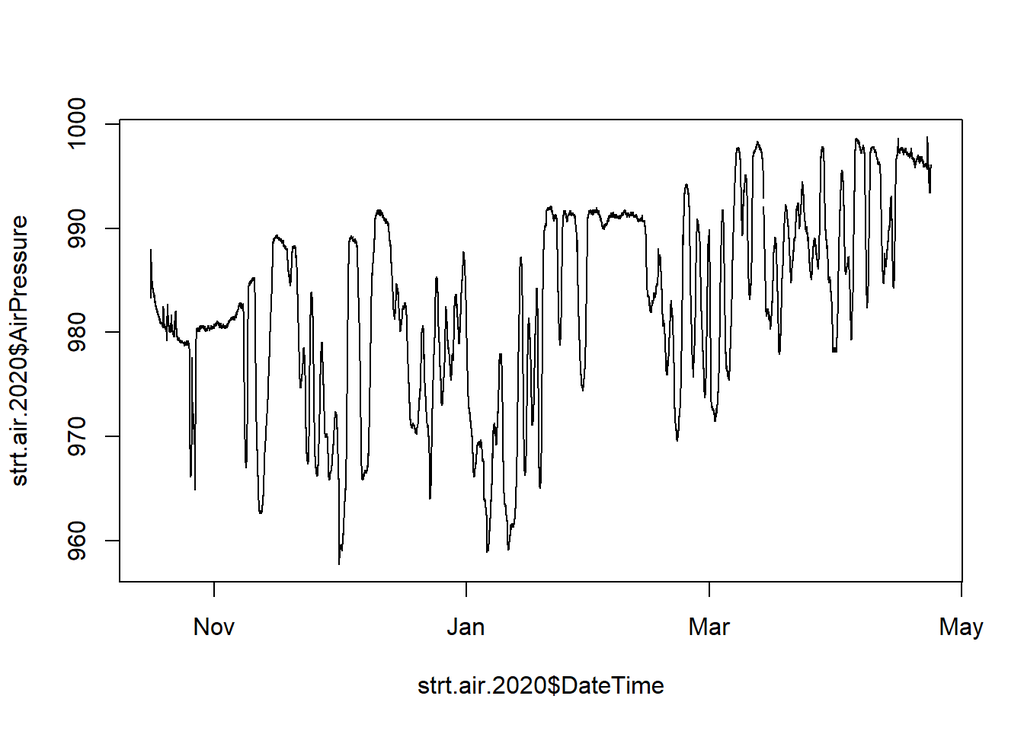

Well that isn’t at all helpful. Lets use air pressure from French.

## Export PT data to csv in DoD_Discharge->PT_data->2020

# Calculate difference

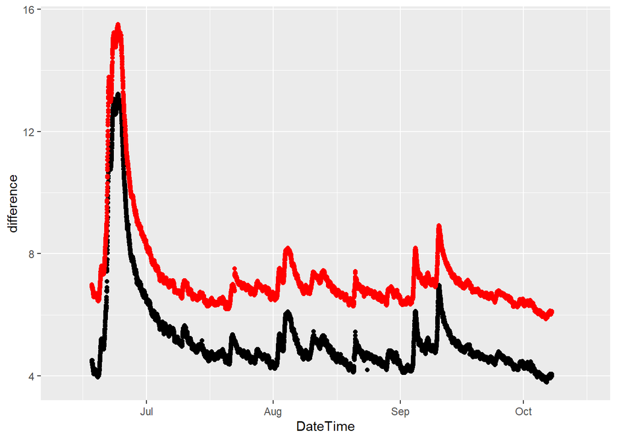

## Raw rating curve for STRT PT1

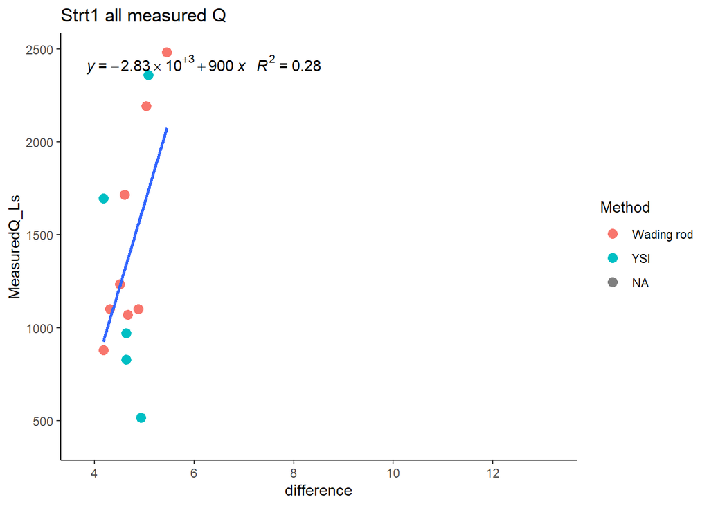

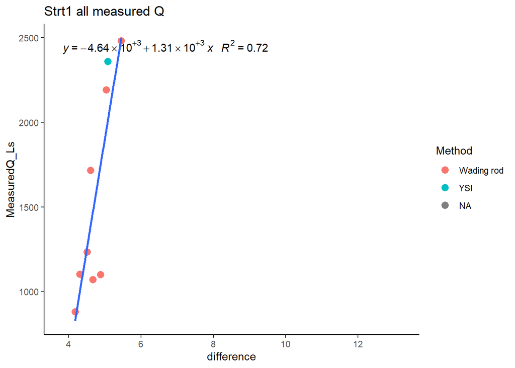

Does not look pretty.

## Rating curve for STRT PT1 2.0

```
##
## Call:
## lm(formula = Strt1comb.2020$MeasuredQ_Ls ~ Strt1comb.2020$difference)
##
## Residuals:
##    Min     1Q Median     3Q    Max
## -552.2 -285.2  109.4  226.6  389.6
##
## Coefficients:
##                           Estimate Std. Error t value Pr(>|t|)
## (Intercept)                -5351.5     1460.4  -3.664  0.00636 **
## Strt1comb.2020$difference   1451.7      309.3   4.694  0.00155 **
## ---
## Signif. codes:  0 '***' 0.001 '**' 0.01 '*' 0.05 '.' 0.1 ' ' 1
##
## Residual standard error: 353.8 on 8 degrees of freedom
##   (12118 observations deleted due to missingness)
## Multiple R-squared:  0.7336, Adjusted R-squared:  0.7003
## F-statistic: 22.03 on 1 and 8 DF,  p-value: 0.001553
```

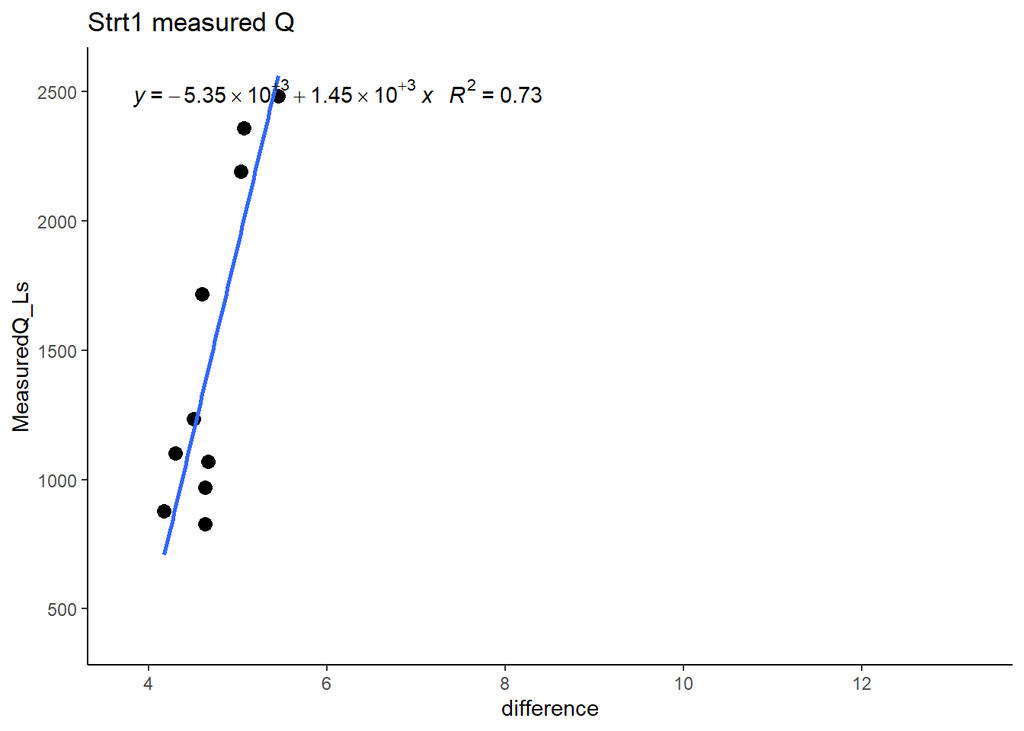

## Raw rating curve for STRT PT2

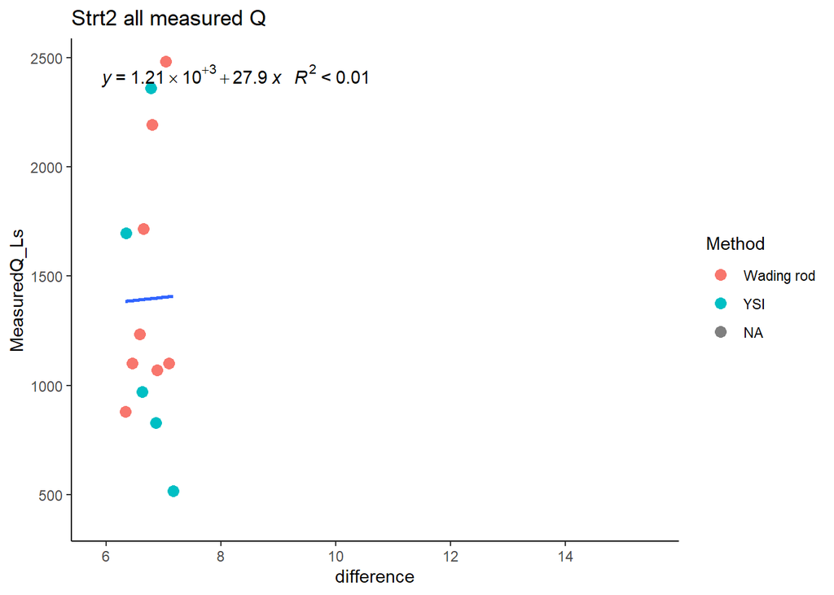

No good.

Rating curve for STRT PT2 2.0

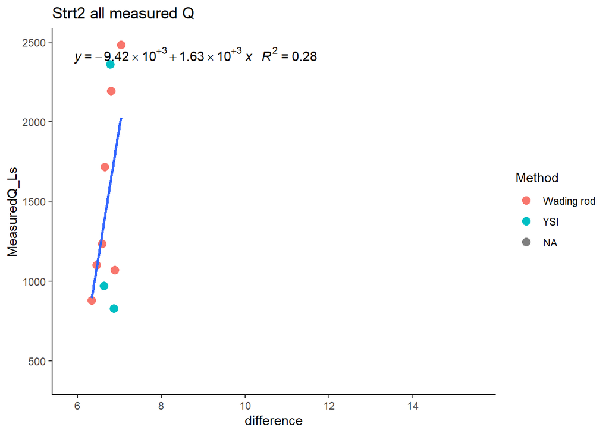

Yikes.

## Predicted Q for STRT PT1

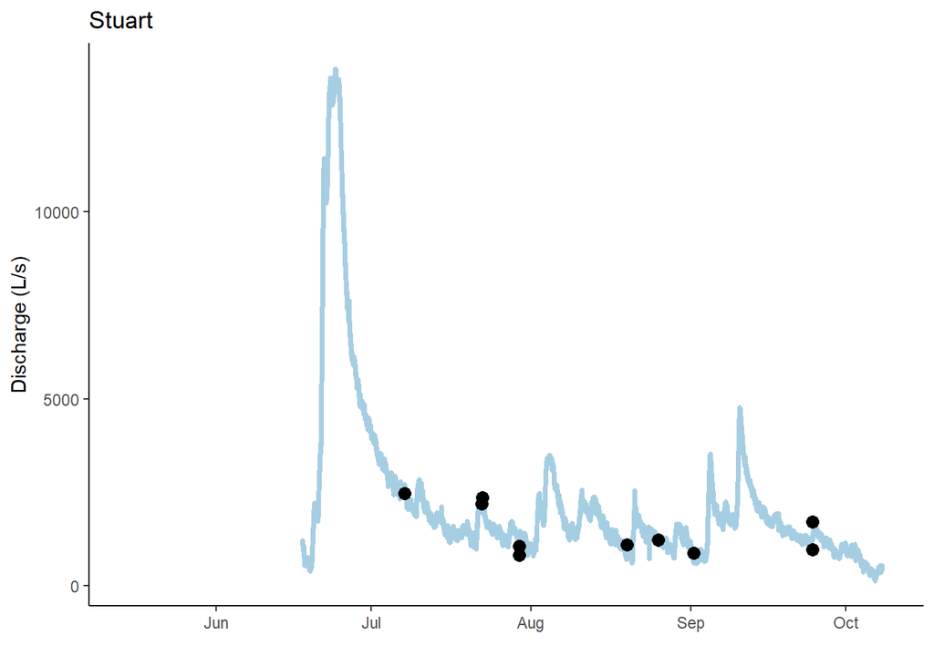

## Predicted Q for STRT PT2

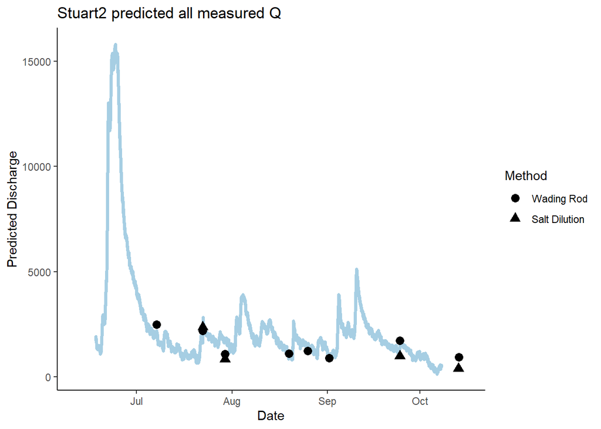

## Predicted Q for STRT

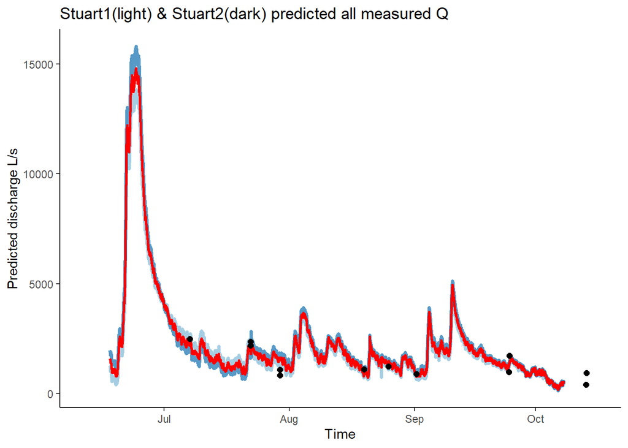

## Export PT data to csv in DoD_Discharge->Predicted_Discharge->2020

## Export PT data to csv in DoD_Discharge->Predicted_Discharge->2020

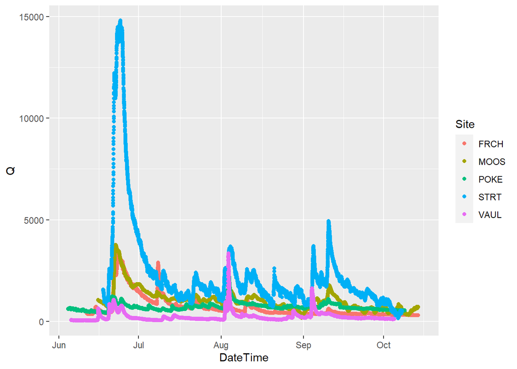

```
## [1] NA 15
```

```
## Defaulting to continuous.
```

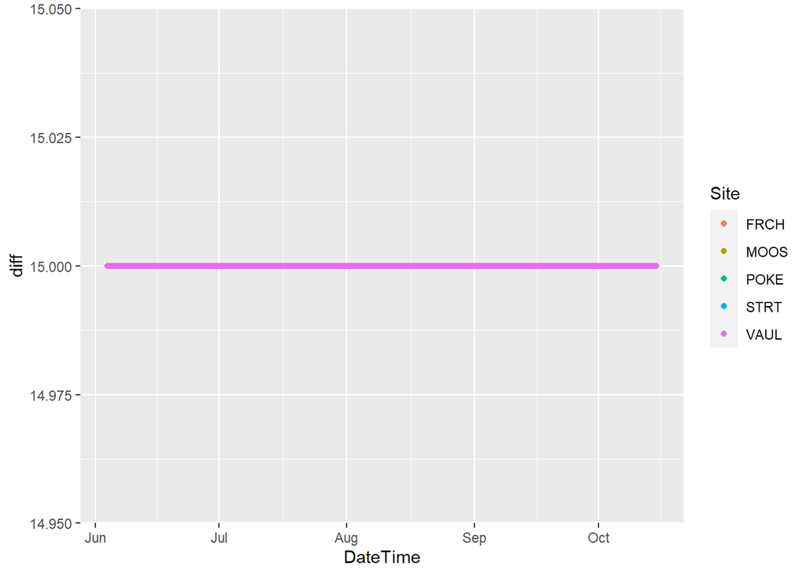

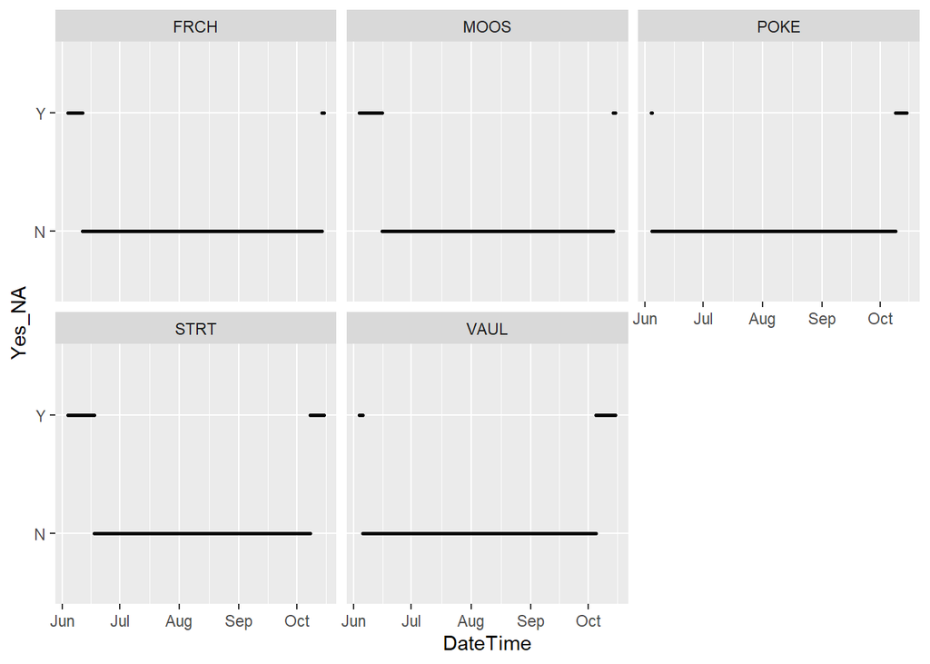